# Beltrame_Ginevra_Rlab06

2024-06-07

## Exercise 1

Ladislaus Josephovich Bortkiewicz was a Russian economist and statistician. He noted that the Poisson distribution can be very useful in applied statistics when describing low-frequency events in a large population. In a famous example he showed that the number of deaths by horse kick among the Prussian army follows the Poisson distribution.

Considering the following two sets of observations taken over a fixed large time interval in two different corps:

```
| y death soldiers  |   0   |   1   |   2   |   3   |   4   |  ≥5   |
|-------------------|-------|-------|-------|-------|-------|-------|
| n1 observations   |  109  |  65   |  22   |   3   |   1   |   0   |
| n2 observations   |  144  |  91   |  32   |  11   |   2   |   0   |
```

1. Assuming a uniform prior, compute and plot the posterior distribution for $λ$, the death rate over the measurement time. Determine the posterior mean, median and variance, and compute the 95% credibility interval.
2. Assuming now a Jeffrey’s prior, $g(λ) ∝ \frac{1}{\sqrt{\lambda}}$ with $λ > 0$, compute and plot the posterior distribution for $λ$, the death rate over the measurement time. Determine the posterior mean, median and variance, and compute the 95% credibility interval.

### Solution

#### (a) Uniform prior

From a theoretical point of view, the Posterior distribution of a Poisson process, assuming a Uniform prior, takes the shape of a $Gamma(\alpha, \beta)$ distribution, with $\alpha = \sum_{j=1}^{N} y_j \cdot n_j + 1$ and $\beta = \sum_{j=1}^{N} n_j$, where $\{n_{1,j}\}_{j=1...N} = \{109, 65, 22, 3, 1, 0\}$ and $\{n_{2,j}\}_{j=1...N} = \{144, 91, 32, 11, 2, 0\}$. It can therefore be computed

$$P_1(\lambda | \{n_{1,j}\}_{j=1...N}) = Gamma(123, 200) \qquad \text{and}
\qquad P_2(\lambda | \{n_{2,j}\}_{j=1...N}) = Gamma(197, 280)$$

As for the median, no closed-form result is readily available but it can be inferred from a sampling of the probability distribution and from a numerical computation of the quantiles.

```r
y <- c(0, 1, 2, 3, 4, 5)
n1 <- c(109, 65, 22, 3, 1, 0)
n2 <- c(144, 91, 32, 11, 2, 0)

shape1 <- sum(n1*y) + 1
rate1 <- sum(n1)

# I calculate the median of the Gamma distribution with a quantile function
median_gamma <- qgamma(0.5, shape = shape1, rate = rate1)
# and the mean and variance with a numerical simulation
set.seed(123)
samples <- rgamma(10000, shape1, rate1)

mean_gamma <- mean(samples)
variance_gamma <- var(samples)

cat('DATASET 1\n')
```

```
## DATASET 1
```

```r
cat("Estimated Mean:", mean_gamma, "\n")
```

```
## Estimated Mean: 0.6140641
```

```r
cat("Estimated Variance:", variance_gamma, "\n")
```

```
## Estimated Variance: 0.003013373
```

```r
cat("Estimated Median:", median_gamma, "\n")
```

```
## Estimated Median: 0.6133341
```

```r
shape2 <- sum(y*n2) + 1
rate2 <- sum(n2)

# I calculate the median of the Gamma distribution with a quantile function
median_gamma <- qgamma(0.5, shape = shape2, rate = rate2)
# and the mean and variance with a numerical simulation
set.seed(123)
samples <- rgamma(10000, shape2, rate2)

mean_gamma <- mean(samples)
variance_gamma <- var(samples)

cat('\nDATASET 2\n')
```

```
##
## DATASET 2
```

```r
cat("Estimated Mean:", mean_gamma, "\n")
```

```
## Estimated Mean: 0.7026637
```

```r
cat("Estimated Variance:", variance_gamma, "\n")
```

```
## Estimated Variance: 0.002468066
```

```r
cat("Estimated Median:", median_gamma, "\n")
```

```
## Estimated Median: 0.7023813
```

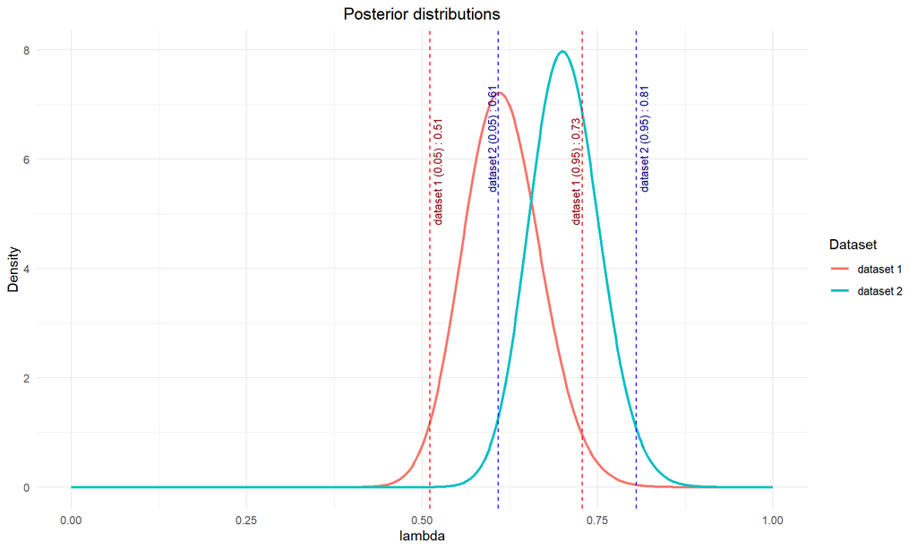

```r
library(ggplot2)

cf <- 0.975

x <- seq(0, 1, length.out = 500)
y1 <- dgamma(x, shape = shape1, rate = rate1)
data1 <- data.frame(x = x, y = y1, group='dataset 1')

y2 <- dgamma(x, shape = shape2, rate = rate2)
data2 <- data.frame(x = x, y = y2, group='dataset 2')

data <- rbind(data1, data2)

p <- ggplot(data, aes(x = x, y = y, color = group)) +
  geom_line(linewidth=1) +
  labs(title = "Posterior distributions", x = "lambda", y = "Density", color='Dataset') +
  theme_minimal() +
  theme(plot.title = element_text(hjust = 0.5))

cf1 <- qgamma(c(1-cf, cf), shape = shape1, rate = rate1)
cf2 <- qgamma(c(1-cf, cf), shape = shape2, rate = rate2)

p +
  geom_vline(xintercept = cf1[1], linetype = "dashed", color = "red", linewidth = 0.5) +
  geom_vline(xintercept = cf1[2], linetype = "dashed", color = "red", linewidth = 0.5) +
  annotate('text', x = cf1[2]-0.01, y = max(y1)*0.8, label = paste("dataset 1 (0.95) :", round(cf1[2], 2)), color = "darkred", size = 3, angle=90) +
  annotate('text', x = cf1[1]+0.01, y = max(y1)*0.8, label = paste("dataset 1 (0.05) :", round(cf1[1], 2)), color = "darkred", size = 3, angle=90) +
  geom_vline(xintercept = cf2[1], linetype = "dashed", color = "blue", linewidth = 0.5) +
  geom_vline(xintercept = cf2[2], linetype = "dashed", color = "blue", linewidth = 0.5) +
  annotate('text', x = cf2[2]+0.01, y = max(y2)*0.8, label = paste("dataset 2 (0.95) :", round(cf2[2], 2)), color = "darkblue", size = 3, angle=90) +
  annotate('text', x = cf2[1]-0.01, y = max(y2)*0.8, label = paste("dataset 2 (0.05) :", round(cf2[1], 2)), color = "darkblue", size = 3, angle=90)
```

#### (b) Jeffrey’s prior

$$P_1(\lambda | \{n_{1,j}\}_{j=1...N}) = Gamma(122.5, 200) \qquad
\text{and} \qquad P_2(\lambda | \{n_{2,j}\}_{j=1...N}) = Gamma(196.5,
280)$$

It is now possible to infer the mean, variance and median from the known theoretical results of the Gamma distribution. Specifically,

$$E_1[\lambda] = \frac{122.5}{200} \approx 0.6125 \qquad Var_1(\lambda) =
\frac{122.5}{200^2} \approx 0.003 \qquad \text{and} \qquad E_2[\lambda]
= \frac{196.5}{280} = 0.7018 \qquad Var_2(\lambda) =
\frac{196.5}{280^2} \approx 0.0025$$

As for the median, no closed-form result is readily available but it can be inferred from a sampling of the probability distribution and from a numerical computation of the quantiles.

```r
y <- c(0, 1, 2, 3, 4, 5)
n1 <- c(109, 65, 22, 3, 1, 0)
n2 <- c(144, 91, 32, 11, 2, 0)

shape1 <- sum(n1*y) + 0.5
rate1 <- sum(n1)

# I calculate the median of the Gamma distribution with a quantile function
median_gamma <- qgamma(0.5, shape = shape1, rate = rate1)
# and the mean and variance with a numerical simulation
set.seed(123)
samples <- rgamma(10000, shape1, rate1)

mean_gamma <- mean(samples)
variance_gamma <- var(samples)

cat('DATASET 1\n')
```

```
## DATASET 1
```

```r
cat("Estimated Mean:", mean_gamma, "\n")
```

```
## Estimated Mean: 0.6115634
```

```r
cat("Estimated Variance:", variance_gamma, "\n")
```

```
## Estimated Variance: 0.003001098
```

```r
cat("Estimated Median:", median_gamma, "\n")
```

```
## Estimated Median: 0.6108341
```

```r
shape2 <- sum(n2*y) + 0.5
rate2 <- sum(n2)

# I calculate the median of the Gamma distribution with a quantile function
median_gamma <- qgamma(0.5, shape = shape2, rate = rate2)
# and the mean and variance with a numerical simulation
set.seed(123)
samples <- rgamma(10000, shape2, rate2)

mean_gamma <- mean(samples)
variance_gamma <- var(samples)

cat('\nDATASET 2\n')
```

```
##
## DATASET 2
```

```r
cat("Estimated Mean:", mean_gamma, "\n")
```

```
## Estimated Mean: 0.7008779
```

```r
cat("Estimated Variance:", variance_gamma, "\n")
```

```
## Estimated Variance: 0.002461793
```

```r
cat("Estimated Median:", median_gamma, "\n")
```

```
## Estimated Median: 0.7005956
```

The analytic results for the mean and variance are compatible with the numerical ones.

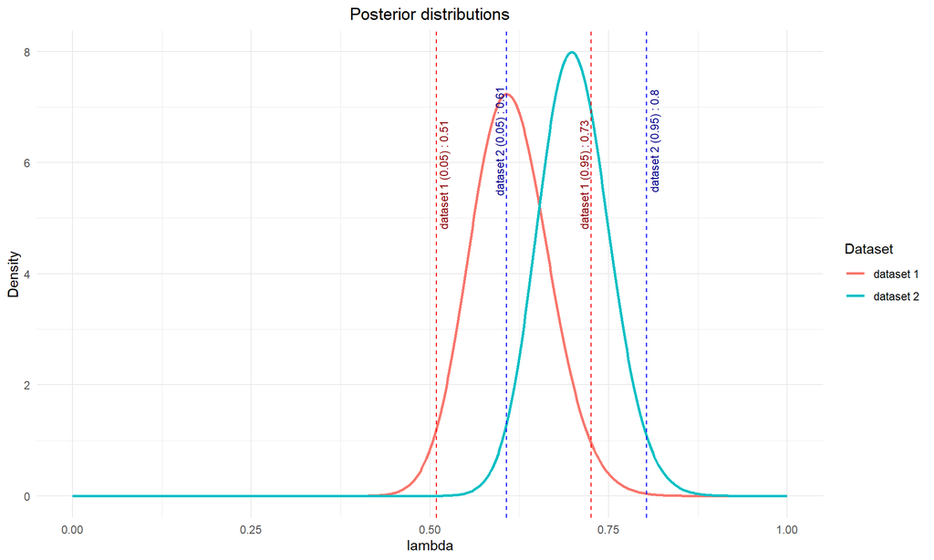

```r
library(ggplot2)

cf <- 0.975

x <- seq(0, 1, length.out = 500)
y1 <- dgamma(x, shape = shape1, rate = rate1)
data1 <- data.frame(x = x, y = y1, group='dataset 1')

y2 <- dgamma(x, shape = shape2, rate = rate2)
data2 <- data.frame(x = x, y = y2, group='dataset 2')

data <- rbind(data1, data2)

p <- ggplot(data, aes(x = x, y = y, color = group)) +
  geom_line(linewidth=1) +
  labs(title = "Posterior distributions", x = "lambda", y = "Density", color='Dataset') +
  theme_minimal() +
  theme(plot.title = element_text(hjust = 0.5))

cf1 <- qgamma(c(1-cf, cf), shape = shape1, rate = rate1)
cf2 <- qgamma(c(1-cf, cf), shape = shape2, rate = rate2)

p +
  geom_vline(xintercept = cf1[1], linetype = "dashed", color = "red", linewidth = 0.5) +
  geom_vline(xintercept = cf1[2], linetype = "dashed", color = "red", linewidth = 0.5) +
  annotate('text', x = cf1[2]-0.01, y = max(y1)*0.8, label = paste("dataset 1 (0.95) :", round(cf1[2], 2)), color = "darkred", size = 3, angle=90) +
  annotate('text', x = cf1[1]+0.01, y = max(y1)*0.8, label = paste("dataset 1 (0.05) :", round(cf1[1], 2)), color = "darkred", size = 3, angle=90) +
  geom_vline(xintercept = cf2[1], linetype = "dashed", color = "blue", linewidth = 0.5) +
  geom_vline(xintercept = cf2[2], linetype = "dashed", color = "blue", linewidth = 0.5) +
  annotate('text', x = cf2[2]+0.01, y = max(y2)*0.8, label = paste("dataset 2 (0.95) :", round(cf2[2], 2)), color = "darkblue", size = 3, angle=90) +
  annotate('text', x = cf2[1]-0.01, y = max(y2)*0.8, label = paste("dataset 2 (0.05) :", round(cf2[1], 2)), color = "darkblue", size = 3, angle=90)
```

## Exercise 2

Solve Exercise 1 using a Markov Chain Monte Carlo using stan.

### Solution

```r
library(rstan)
options(mc.cores=parallel::detectCores())
# on my machine:
parallel::detectCores()
```

```
## [1] 4
```

```r
rstan_options(auto_write = TRUE)

y <- c(0, 1, 2, 3, 4, 5)
n1 <- c(109, 65, 22, 3, 1, 0)
n2 <- c(144, 91, 32, 11, 2, 0)
```

#### (a) Uniform prior

```r
x <- c(rep(y[1], n1[1]), rep(y[2], n1[2]), rep(y[3], n1[3]), rep(y[4], n1[4]), rep(y[5], n1[5]), rep(y[6], n1[6]))

dataList <- list(Y = x, N = length(x))

modelString = "
  data {
    int<lower=0> N;
    int Y[N];
  }
  parameters {
    real<lower=0> lambda;
  }
  model {
    lambda ~ uniform(0,1000);
    Y ~ poisson(lambda);
  }
"
writeLines(modelString, con="stan_Poisson_model_Uniform.stan")

stanDso <- stan_model(model_code=modelString)
n_chains <- 3
# initialization with the mean value of lambda estimated in Exercise 1
initializers_list <- replicate(n_chains, list(lambda = 0.6), simplify = FALSE)

stanFit <- sampling(
  object = stanDso,
  data = dataList,
  chains = n_chains,
  iter = 1000,
  warmup = 200,
  thin = 1,
  init = initializers_list
  )


library(coda)
mcmcCoda <- mcmc.list(lapply(1:ncol(stanFit), function(lambda) {mcmc(as.array(stanFit)[, lambda,])} ))
summary(mcmcCoda)
```

```
##
## Iterations = 1:800
## Thinning interval = 1
## Number of chains = 3
## Sample size per chain = 800
##
## 1. Empirical mean and standard deviation for each variable,
##    plus standard error of the mean:
##
##             Mean      SD Naive SE Time-series SE
## lambda    0.6142 0.05497 0.001122       0.001917
## lp__   -183.2883 0.70384 0.014367       0.021117
##
## 2. Quantiles for each variable:
##
##             2.5%       25%       50%       75%     97.5%
## lambda    0.5101    0.5759    0.6127    0.6503    0.7273
## lp__   -185.4024 -183.4370 -183.0223 -182.8454 -182.7951
```

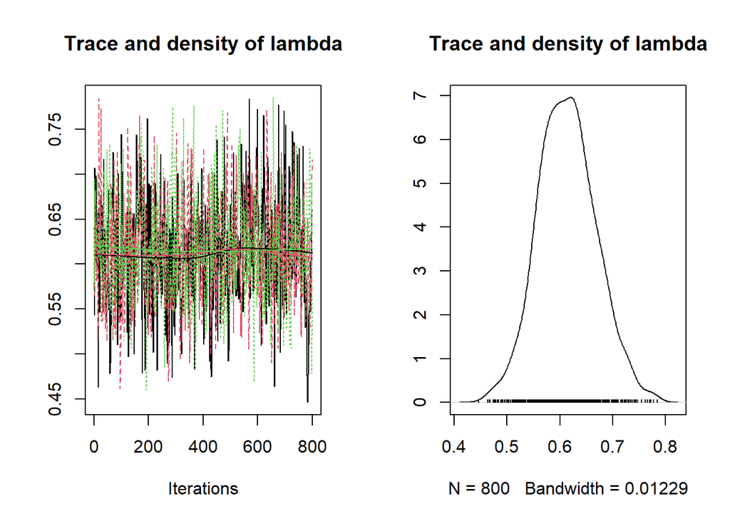

```r
plot(mcmcCoda[, 'lambda'], main='Trace and density of lambda')
```

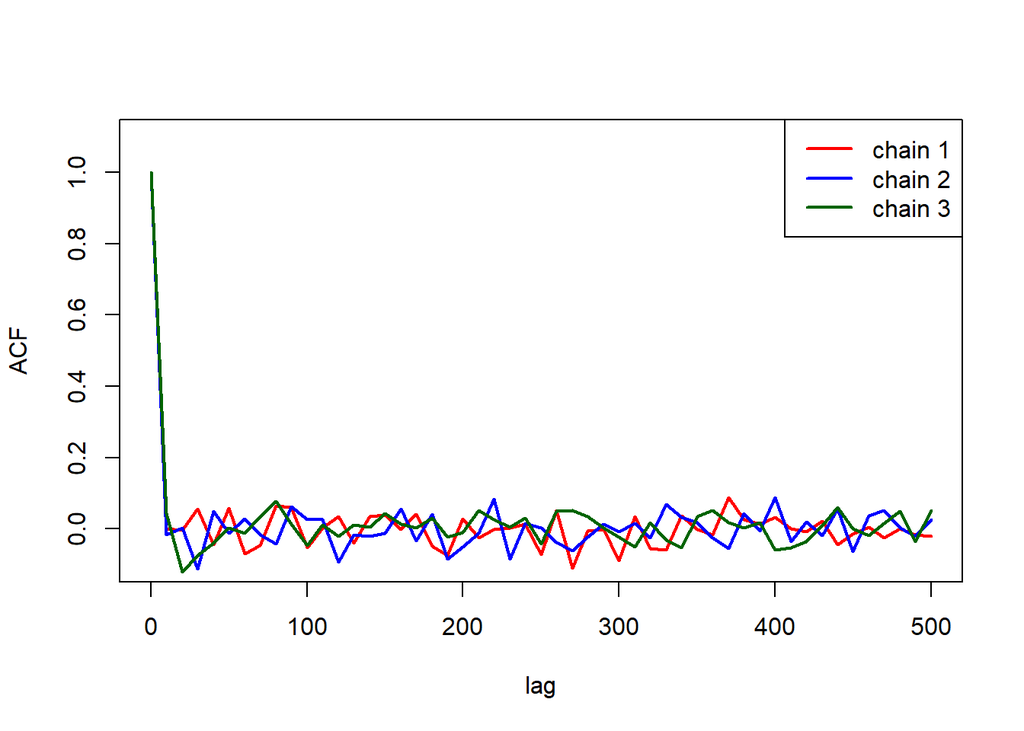

```r
my.lags = seq(0,500,10)
y1 <- autocorr(mcmcCoda, lags=my.lags)
colors <- c('red', 'blue', 'darkgreen', 'orange', 'violet')

plot(my.lags, my.lags, ylim=c(-0.1,1.1), xlab='lag', ylab='ACF', col='white')
for (i in 1:n_chains){
  lines(my.lags, y1[[i]][, ,'lambda'][,'lambda'], col=colors[i], lwd=2)
}

legend("topright", legend=c('chain 1', 'chain 2', 'chain 3', 'chain 4', 'chain 5')[1:n_chains], col=colors, lty=1, lwd = 2)
```

```r
x <- c(rep(y[1], n2[1]), rep(y[2], n2[2]), rep(y[3], n2[3]), rep(y[4], n2[4]), rep(y[5], n2[5]), rep(y[6], n2[6]))

dataList <- list(Y = x, N = length(x))

modelString = "
  data {
    int<lower=0> N;
    int Y[N];
  }
  parameters {
    real<lower=0> lambda;
  }
  model {
    lambda ~ uniform(0,1000);
    Y ~ poisson(lambda);
  }
"
writeLines(modelString, con="stan_Poisson_model_Uniform.stan")

stanDso <- stan_model(model_code=modelString)
n_chains <- 3
# initialization with the mean value of lambda estimated in Exercise 1
initializers_list <- replicate(n_chains, list(lambda = 0.7), simplify = FALSE)

stanFit <- sampling(
  object = stanDso,
  data = dataList,
  chains = n_chains,
  iter = 1000,
  warmup = 200,
  thin = 1,
  init = initializers_list
  )


library(coda)
mcmcCoda <- mcmc.list(lapply(1:ncol(stanFit), function(lambda) {mcmc(as.array(stanFit)[, lambda,])} ))
summary(mcmcCoda)
```

```
##
## Iterations = 1:800
## Thinning interval = 1
## Number of chains = 3
## Sample size per chain = 800
##
## 1. Empirical mean and standard deviation for each variable,
##    plus standard error of the mean:
##
##             Mean      SD Naive SE Time-series SE
## lambda    0.7045 0.05097  0.00104       0.001698
## lp__   -266.7813 0.74068  0.01512       0.022052
##
## 2. Quantiles for each variable:
##
##            2.5%       25%       50%      75%     97.5%
## lambda    0.603    0.6694    0.7052    0.738    0.8053
## lp__   -268.912 -266.9479 -266.4955 -266.313 -266.2629
```

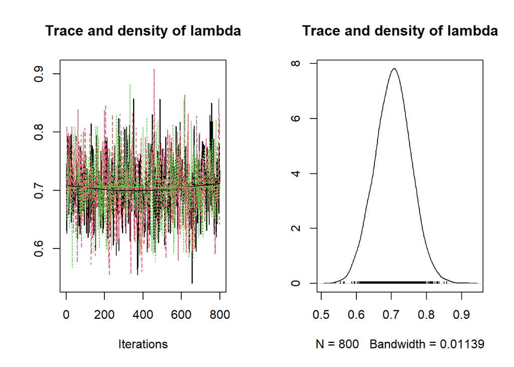

```r
plot(mcmcCoda[, 'lambda'], main='Trace and density of lambda')
```

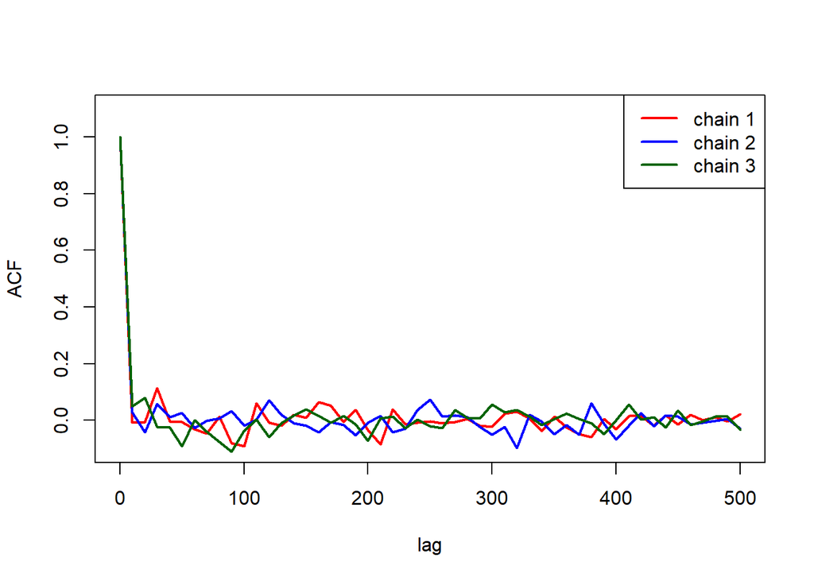

```r
my.lags = seq(0,500,10)
y1 <- autocorr(mcmcCoda, lags=my.lags)
colors <- c('red', 'blue', 'darkgreen', 'orange', 'violet')

plot(my.lags, my.lags, ylim=c(-0.1,1.1), xlab='lag', ylab='ACF', col='white')
for (i in 1:n_chains){
  lines(my.lags, y1[[i]][, ,'lambda'][,'lambda'], col=colors[i], lwd=2)
}

legend("topright", legend=c('chain 1', 'chain 2', 'chain 3', 'chain 4', 'chain 5')[1:n_chains], col=colors, lty=1, lwd = 2)
```

#### (b) Jeffrey’s prior

```r
x <- c(rep(y[1], n1[1]), rep(y[2], n1[2]), rep(y[3], n1[3]), rep(y[4], n1[4]), rep(y[5], n1[5]), rep(y[6], n1[6]))

dataList <- list(Y = x, N = length(x))

modelString = "
  data {
    int<lower=0> N;
    int Y[N];
  }
  parameters {
    real<lower=0> lambda;
  }
  model {
    lambda ~ gamma(0.5, 0.0001);
    Y ~ poisson(lambda);
  }
"
writeLines(modelString, con="stan_Poisson_model_Jeffreys.stan")

stanDso <- stan_model(model_code=modelString)
n_chains <- 3
# initialization with the mean value of lambda estimated in Exercise 1
initializers_list <- replicate(n_chains, list(lambda = 0.6), simplify = FALSE)

stanFit <- sampling(
  object = stanDso,
  data = dataList,
  chains = n_chains,
  iter = 1000,
  warmup = 200,
  thin = 1,
  init = initializers_list
  )


library(coda)
mcmcCoda <- mcmc.list(lapply(1:ncol(stanFit), function(lambda) {mcmc(as.array(stanFit)[, lambda,])} ))
summary(mcmcCoda)
```

```
##
## Iterations = 1:800
## Thinning interval = 1
## Number of chains = 3
## Sample size per chain = 800
##
## 1. Empirical mean and standard deviation for each variable,
##    plus standard error of the mean:
##
##             Mean      SD Naive SE Time-series SE
## lambda    0.6143 0.05339  0.00109       0.001707
## lp__   -183.0148 0.63463  0.01295       0.018674
##
## 2. Quantiles for each variable:
##
##             2.5%       25%      50%       75%     97.5%
## lambda    0.5112    0.5792    0.613    0.6491    0.7224
## lp__   -184.8705 -183.1845 -182.749 -182.5935 -182.5508
```

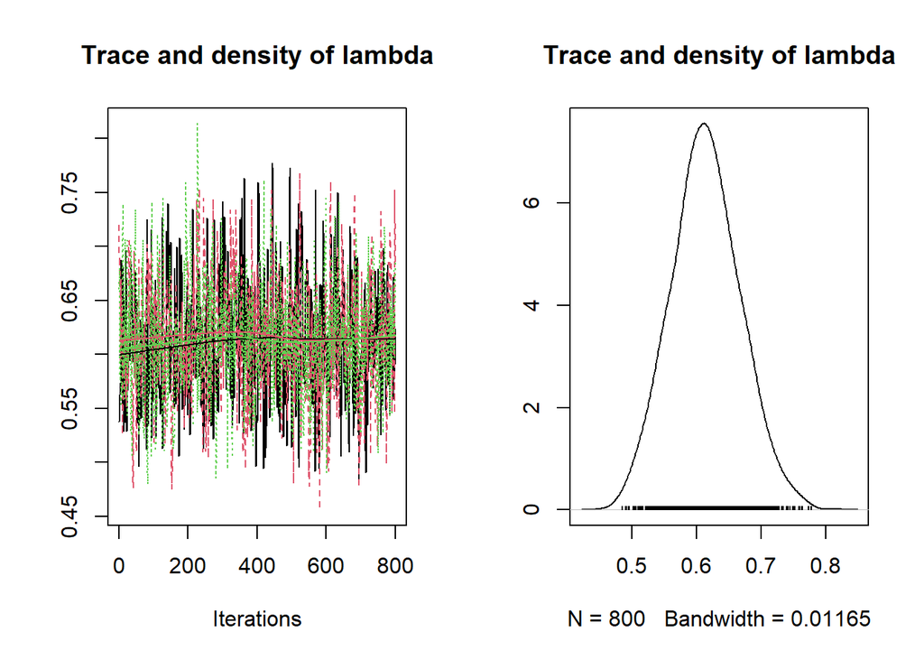

```r
plot(mcmcCoda[, 'lambda'], main='Trace and density of lambda')
```

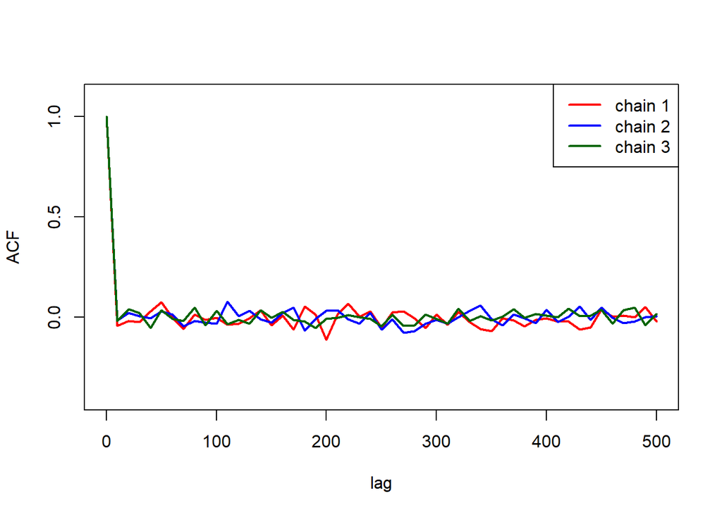

```r
my.lags = seq(0,500,10)
y1 <- autocorr(mcmcCoda, lags=my.lags)
colors <- c('red', 'blue', 'darkgreen', 'orange', 'violet')

plot(my.lags, my.lags, ylim=c(-0.4,1.1), xlab='lag', ylab='ACF', col='white')
for (i in 1:n_chains){
  lines(my.lags, y1[[i]][, ,'lambda'][,'lambda'], col=colors[i], lwd=2)
}

legend("topright", legend=c('chain 1', 'chain 2', 'chain 3', 'chain 4', 'chain 5')[1:n_chains], col=colors, lty=1, lwd = 2)
```

```r
x <- c(rep(y[1], n2[1]), rep(y[2], n2[2]), rep(y[3], n2[3]), rep(y[4], n2[4]), rep(y[5], n2[5]), rep(y[6], n2[6]))

dataList <- list(Y = x, N = length(x))

modelString = "
  data {
    int<lower=0> N;
    int Y[N];
  }
  parameters {
    real<lower=0> lambda;
  }
  model {
    lambda ~ gamma(0.5, 0.0001);
    Y ~ poisson(lambda);
  }
"
writeLines(modelString, con="stan_Poisson_model_Jeffreys.stan")

stanDso <- stan_model(model_code=modelString)
n_chains <- 3
# initialization with the mean value of lambda estimated in Exercise 1
initializers_list <- replicate(n_chains, list(lambda = 0.7), simplify = FALSE)

stanFit <- sampling(
  object = stanDso,
  data = dataList,
  chains = n_chains,
  iter = 1000,
  warmup = 200,
  thin = 1,
  init = initializers_list
  )


library(coda)
mcmcCoda <- mcmc.list(lapply(1:ncol(stanFit), function(lambda) {mcmc(as.array(stanFit)[, lambda,])} ))
summary(mcmcCoda)
```

```
##
## Iterations = 1:800
## Thinning interval = 1
## Number of chains = 3
## Sample size per chain = 800
##
## 1. Empirical mean and standard deviation for each variable,
##    plus standard error of the mean:
##
##             Mean      SD Naive SE Time-series SE
## lambda    0.7027 0.04958 0.001012       0.001666
## lp__   -266.5757 0.69015 0.014088       0.021633
##
## 2. Quantiles for each variable:
##
##             2.5%       25%      50%       75%     97.5%
## lambda    0.6096    0.6686    0.701    0.7361    0.8044
## lp__   -268.6578 -266.7302 -266.314 -266.1384 -266.0866
```

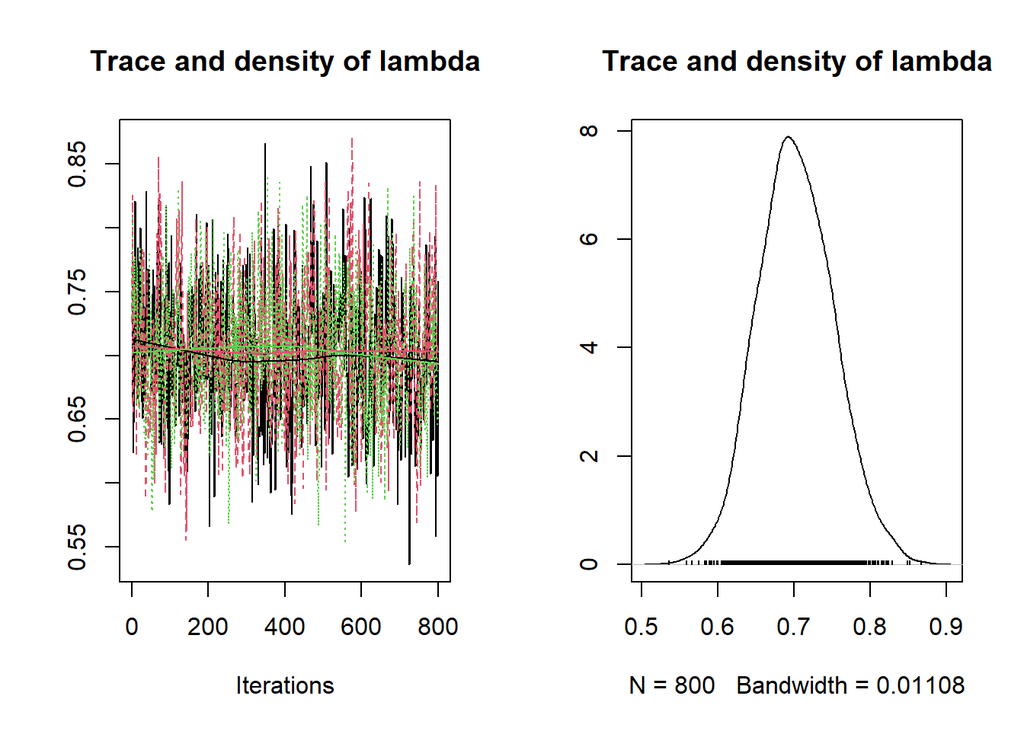

```r
plot(mcmcCoda[, 'lambda'], main='Trace and density of lambda')
```

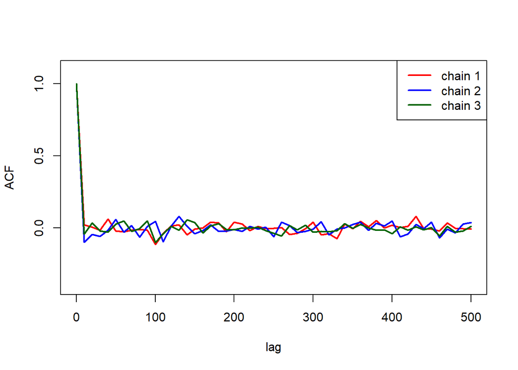

```r
my.lags = seq(0,500,10)
y1 <- autocorr(mcmcCoda, lags=my.lags)
colors <- c('red', 'blue', 'darkgreen', 'orange', 'violet')

plot(my.lags, my.lags, ylim=c(-0.4,1.1), xlab='lag', ylab='ACF', col='white')
for (i in 1:n_chains){
  lines(my.lags, y1[[i]][, ,'lambda'][,'lambda'], col=colors[i], lwd=2)
}

legend("topright", legend=c('chain 1', 'chain 2', 'chain 3', 'chain 4', 'chain 5')[1:n_chains], col=colors, lty=1, lwd = 2)
```

## Exercise 3

A study on water quality of streams, a high level of bacter X was defined as a level greater than 100 per 100 ml of stream water. $n = 116$ samples were taken from streams having a high environmental impact on pandas. Out of these, $y = 11$ had a high bacter X level.

Indicating with $p$ the probability that a sample of water taken from the stream has a high bacter X level,

1. find the frequentist estimator for $p$
2. using a $Beta(1, 10)$ prior for $p$, calculate and posterior distribution $P(p | y)$
3. find the bayesian estimator for $p$, the posterior mean and variance, and a 95% credible interval
4. test the hypothesis

$$H_0 : p = 0.1 \qquad \text{versus} \qquad H_1 : p \neq 0.1$$

at 5% level of significance with both the frequentist and bayesian approach.

A new measurement, performed one month later on $n = 165$ water samples, gives $y = 9$ high bacter X level

5. find the frequentist estimator for $p$
6. find a bayesian estimator for $p$, assuming both a $Beta(1, 10)$ prior for $p$, and assuming the posterior probability of the older measurement as the prior for the new one.
7. find the bayesian estimator for $p$, the posterior mean and variance, and a 95% credible interval
8. test the hypothesis

$$H_0 : p = 0.1 \qquad \text{versus} \qquad H_1 : p \neq 0.1$$

at 5% level of significance with both the frequentist and bayesian approach.

### Solution

#### (a) Frequentist approach posterior

In the frequentist paradigm, the probability $p$ that a sample of water taken from the stream has a high bacter X level is fixed and equal to

$$\hat{p}_F = \frac{y}{n} = \frac{11}{116} \approx 0.0948$$

The properties of the estimator are the following.

$$E[\hat{p}_F] = p \qquad Var[\hat{p}_F] = \frac{p(1 − p)}{n} \qquad
\text{so} \qquad Std[\hat{p}_F] = \sqrt{\frac{p(1 − p)}{n}}$$

Therefore, the pdf of the parameter $\hat{p}_F$ is given by a Binomial distribution with the determined mean $\mu = \hat{p}\_F \approx 0.0948$ and standard deviation $\sigma = \sqrt{\frac{p(1 − p)}{n}} \approx 0.0272$.

#### (b) Bayesian approach posterior

Assuming now a prior of the type $Beta(a, b) = Beta(1, 10)$ for $p$, the posterior distribution is given by a Beta function as well, since a Beta prior is a conjugate function for the Binomial distribution and this is a binomial process.

$$Beta(a'=a+y, \ b'=b+n-y) = Beta(12, 115)$$

#### (c) Bayesian pdf parameters

Having determined the shape of the Beta posterior distribution for $p$, it is now possible to calculate the mean, variance and 95% credibility intervals of such an estimator. Specifically,

$$E[p_B] = \frac{\alpha}{\alpha + \beta} = \frac{12}{127} \approx 0.0945
\qquad Var(p_B) = \frac{\alpha \beta}{(\alpha + \beta)^2 (\alpha + \beta
+ 1)} = \frac{12 \cdot 115}{127^2 \cdot 128} \approx 0.0007 \qquad
\text{so} \qquad \sigma \approx 0.026$$

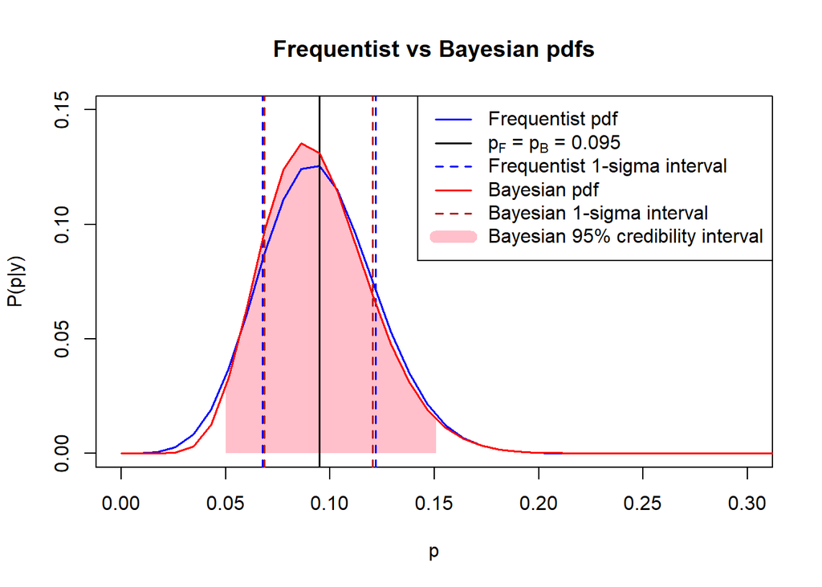

```r
n <- 116
y <- 11

x <- 0:n
rate <- seq(0, 1, 1/n)
freq_p <- dbinom(x, size = n, prob = y/n)
plot(rate, freq_p, type = "l", main='Frequentist vs Bayesian pdfs', ylim=c(0, 0.15), xlim=c(0, 0.3), lty=1, lwd=1.5, col='white', xlab='p', ylab='P(p|y)')

mu <- y/n
sigma <- sqrt(mu*(1-mu)/n)

bayes_p <- dbeta(rate, 12, 115)
norm <- sum(dbeta(rate, 12, 115))

set.seed(123)
samples <- rbeta(10000, 12, 115)

mean <- mean(samples)
variance <- var(samples)

cf <- 0.975
cf_B <- qbeta(c(1-cf, cf), 12, 115)

rate_red <- rate[rate >= cf_B[1] & rate <= cf_B[2]]
pdf_red <- bayes_p[rate >= cf_B[1] & rate <= cf_B[2]]/norm
polygon(c(cf_B[1], cf_B[1], rate_red, cf_B[2], cf_B[2]), c(0, 0.03, pdf_red, 0.015, 0), col = "pink", border = NA)


lines(rate, freq_p, lty=1, lwd=1.5, col='blue')
abline(v=mu, col='black', lwd=1.5, lty=1)
abline(v=mu + sigma, col='blue', lwd=1.5, lty=2)
abline(v=mu - sigma, col='blue', lwd=1.5, lty=2)
lines(rate, bayes_p/norm, col='red', lwd=1.5, lty=1)
abline(v=mean + sqrt(variance), col='firebrick', lwd=1.5, lty=2)
abline(v=mean - sqrt(variance), col='firebrick', lwd=1.5, lty=2)

leg.colors <- c('blue', 'black', 'blue', 'red', 'firebrick', 'pink')
leg.labels <- c('Frequentist pdf', expression(paste(p[F], ' = ', p[B], ' = 0.095')), 'Frequentist 1-sigma interval', 'Bayesian pdf', 'Bayesian 1-sigma interval', 'Bayesian 95% credibility interval')
leg.ltypes <- c(1, 1, 2, 1, 2, 1)
leg.lwidths <- c(1.5, 1.5, 1.5, 1.5, 1.5, 10)
legend("topright", legend=leg.labels, lty=leg.ltypes, col=leg.colors, lwd=leg.lwidths)
```

#### (d) Hypothesis testing

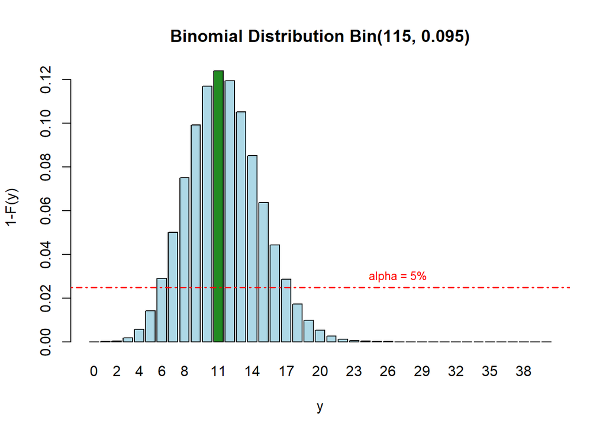

```r
n <- 115
p <- 0.1

# Generate the possible values of y (number of successes)
y_values <- 0:n

# Calculate the probabilities for each value of y
probabilities <- dbinom(y_values, size = n, prob = p)
colors <- rep("lightblue", length(y_values))
colors[y_values == 11] <- "forestgreen"

# Create a bar plot of the probabilities
barplot(probabilities[1:41], names.arg = y_values[0:41], main = "Binomial Distribution Bin(115, 0.095)", xlab = "y", ylab = "1-F(y)", col = colors, border = "black")
abline(h=0.025, lty=4, col='red', lwd=1.5)
text(33, 0.03, 'alpha = 5%', col='red', cex=0.8)
```

The null hypothesis is clearly accepted, as it does not lie in the rejection region for this level of significance. The frequentist result can also be obtained by means of a test implemented in R:

```r
binom.test(x=11, n=115, p=0.1, alternative = "two.sided")
```

```
##
##  Exact binomial test
##
## data:  11 and 115
## number of successes = 11, number of trials = 115, p-value = 1
## alternative hypothesis: true probability of success is not equal to 0.1
## 95 percent confidence interval:
##  0.04872277 0.16470445
## sample estimates:
## probability of success
##             0.09565217
```

As for a Bayesian approach to solve this problem, it can be observed in the plot at point (c) that the value $p=0.1$ falls well within the 95% credibility interval, and therefore the two-sides test cannot reject $H_0$.

#### (e) Frequentist approach posterior

In the frequentist paradigm, the probability $p$ that a sample of water taken from the stream has a high bacter X level is fixed and equal to

$$\hat{p}_F = \frac{y}{n} = \frac{9}{165} \approx 0.0545$$

#### (f) Bayesian approach posterior

Assuming now a prior of the type $Beta(a, b) = Beta(1, 10)$ for $p$, the posterior distribution is given by a Beta function as well, since a Beta prior is a conjugate function for the Binomial distribution and this is a binomial process.

$$P_1(p|y) = Beta(a'=a+y, \ b'=b+n-y) = Beta(10, 166)$$

Alternatively, one could assume as a prior for $p$ the posterior given by the previous data collection, $Beta(12,115)$.

$$P_2(p|y) = Beta(a'=a+y, \ b'=b+n-y) = Beta(21, 271)$$

#### (g) Bayesian pdf parameters

Having determined the two possible shapes of the Beta posterior distribution for $p$, it is now possible to calculate the mean, variance and 95% credibility intervals of such estimators. Specifically,

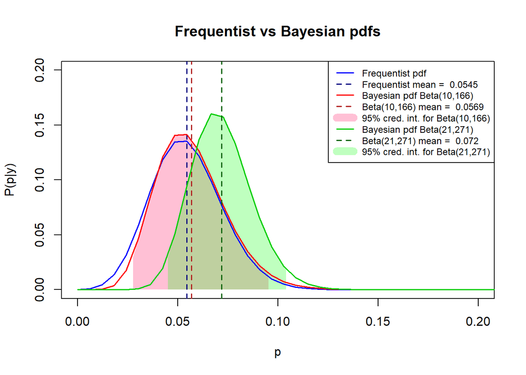

```r
n <- 165
y <- 9

x <- 0:n
rate <- seq(0, 1, 1/n)
freq_p <- dbinom(x, size = n, prob = y/n)
plot(rate, freq_p, type = "l", main='Frequentist vs Bayesian pdfs', ylim=c(0, 0.2), xlim=c(0, 0.2), lty=1, lwd=1.5, col='white', xlab='p', ylab='P(p|y)')

mu <- y/n
sigma <- sqrt(mu*(1-mu)/n)

alpha1 <- 10
beta1 <- 166
bayes_p1 <- dbeta(rate, alpha1, beta1)
norm1 <- sum(dbeta(rate, alpha1, beta1))

set.seed(123)
samples1 <- rbeta(10000, alpha1, beta1)

mean1 <- mean(samples1)
variance1 <- var(samples1)

cf <- 0.975
cf_B1 <- qbeta(c(1-cf, cf), alpha1, beta1)

rate_red1 <- rate[rate >= cf_B1[1] & rate <= cf_B1[2]]
pdf_red1 <- bayes_p1[rate >= cf_B1[1] & rate <= cf_B1[2]]/norm1
polygon(c(cf_B1[1], cf_B1[1], rate_red1, cf_B1[2], cf_B1[2]), c(0, 0.03, pdf_red1, 0.015, 0), col = rgb(255/255, 130/255, 171/255, 0.5), border = NA)


alpha2 <- 21
beta2 <- 271
bayes_p2 <- dbeta(rate, alpha2, beta2)
norm2 <- sum(dbeta(rate, alpha2, beta2))

set.seed(123)
samples2 <- rbeta(10000, alpha2, beta2)

mean2 <- mean(samples2)
variance2 <- var(samples2)

cf <- 0.975
cf_B2 <- qbeta(c(1-cf, cf), alpha2, beta2)

rate_red2 <- rate[rate >= cf_B2[1] & rate <= cf_B2[2]]
pdf_red2 <- bayes_p2[rate >= cf_B2[1] & rate <= cf_B2[2]]/norm2
polygon(c(cf_B2[1], cf_B2[1], rate_red2, cf_B2[2], cf_B2[2]), c(0, 0.03, pdf_red2, 0.02, 0), col = rgb(0/255, 255/255, 0/255, 0.25), border = NA)


lines(rate, freq_p, lty=1, lwd=1.5, col='blue')
abline(v=mu, col='navy', lwd=1.5, lty=2)
lines(rate, bayes_p1/norm1, col='red', lwd=1.5, lty=1)
abline(v=mean1, col='firebrick', lwd=1.5, lty=2)
lines(rate, bayes_p2/norm2, col='green3', lwd=1.5, lty=1)
abline(v=mean2, col='darkgreen', lwd=1.5, lty=2)

leg.colors <- c('blue', 'navy', 'red', 'firebrick', rgb(255/255, 130/255, 171/255, 0.5), 'green3', 'darkgreen', rgb(0/255, 255/255, 0/255, 0.25))
leg.labels <- c('Frequentist pdf', paste('Frequentist mean = ', signif(mu, 3)), 'Bayesian pdf Beta(10,166)', paste('Beta(10,166) mean = ', signif(mean1, 3)), '95% cred. int. for Beta(10,166)', 'Bayesian pdf Beta(21,271)', paste('Beta(21,271) mean = ', signif(mean2, 3)), '95% cred. int. for Beta(21,271)')
leg.ltypes <- c(1, 2, 1, 2, 1, 1, 2, 1)
leg.lwidths <- c(1.5, 1.5, 1.5, 1.5, 10, 1.5, 1.5, 10)
legend("topright", legend=leg.labels, lty=leg.ltypes, col=leg.colors, lwd=leg.lwidths, cex=0.75)
```

#### (h) Hypothesis Testing

Frequentist test in R:

```r
binom.test(x=9, n=165, p=0.1, alternative = "two.sided")
```

```
##
##  Exact binomial test
##
## data:  9 and 165
## number of successes = 9, number of trials = 165, p-value = 0.05112
## alternative hypothesis: true probability of success is not equal to 0.1
## 95 percent confidence interval:
##  0.02524192 0.10101679
## sample estimates:
## probability of success
##             0.05454545
```

The null hypothesis is therefore not rejected by the test. As for a Bayesian approach to solve this problem, it can be observed in the plot at point (g) that the value $p=0.1$ falls outside the 95% credibility interval for the $Beta(1, 10)$ choice of the prior, while $H_0$ is instead accepted by assuming $Beta(12,115)$ as a prior.

## Exercise 4

Analyze the data of Exercise 3 and solve points (b) and (c) using a Markov Chain Monte Carlo using stan.

### Solution

```r
library(rstan)
options(mc.cores=parallel::detectCores())
parallel::detectCores()
```

```
## [1] 4
```

```r
rstan_options(auto_write = TRUE)

n <- 115
y <- 11
dataList <- list(n=n, y=y)

modelString = "
  data {
    int<lower=0> n;
    int y;
  }
  parameters {
    real<lower=0,upper=1> p;
  }
  model {
    p ~ beta(1, 10);
    y ~ binomial(n, p);
  }
"
writeLines(modelString, con="stan_Binomial_model.stan")

stanDso <- stan_model(model_code=modelString)
n_chains <- 2
# initialization with the mean value of p estimated in Exercise 3
initializers_list <- replicate(n_chains, list(p = 0.095), simplify = FALSE)

stanFit <- sampling(
  object = stanDso,
  data = dataList,
  chains = n_chains,
  iter = 1000,
  warmup = 200,
  thin = 1,
  init = initializers_list
  )


library(coda)
mcmcCoda <- mcmc.list(lapply(1:ncol(stanFit), function(p) {mcmc(as.array(stanFit)[, p,])} ))
summary(mcmcCoda)
```

```
##
## Iterations = 1:800
## Thinning interval = 1
## Number of chains = 2
## Sample size per chain = 800
##
## 1. Empirical mean and standard deviation for each variable,
##    plus standard error of the mean:
##
##           Mean     SD  Naive SE Time-series SE
## p      0.09553 0.0252 0.0006299       0.001015
## lp__ -40.09956 0.6509 0.0162731       0.026467
##
## 2. Quantiles for each variable:
##
##           2.5%       25%       50%      75%    97.5%
## p      0.05304   0.07686   0.09265   0.1123   0.1497
## lp__ -41.78123 -40.27304 -39.85796 -39.6808 -39.6266
```

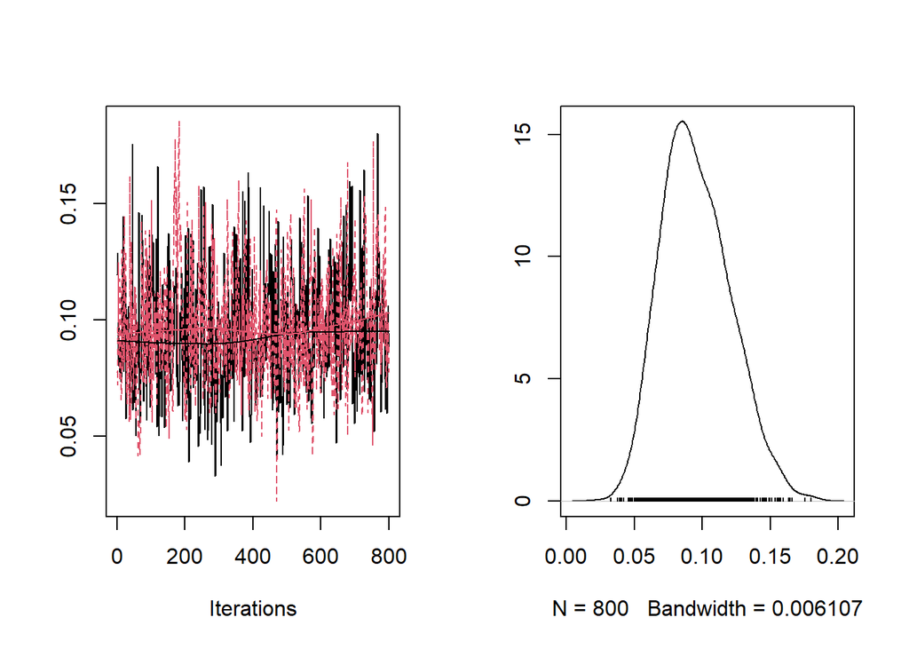

```r
plot(mcmcCoda[, 'p'])
```

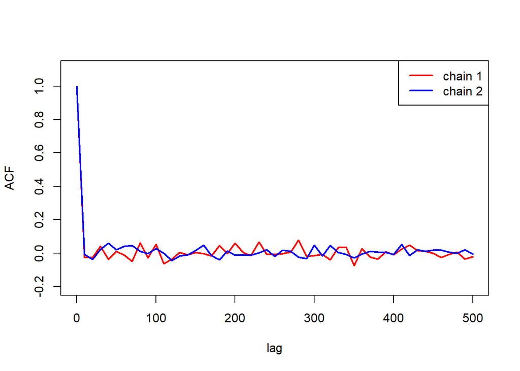

```r
my.lags = seq(0,500,10)
y1 <- autocorr(mcmcCoda, lags=my.lags)
colors <- c('red', 'blue', 'darkgreen', 'orange', 'violet')

plot(my.lags, my.lags, ylim=c(-0.2,1.1), xlab='lag', ylab='ACF', col='white')
for (i in 1:n_chains){
  lines(my.lags, y1[[i]][, ,'p'][,'p'], col=colors[i], lwd=2)
}

legend("topright", legend=c('chain 1', 'chain 2', 'chain 3', 'chain 4', 'chain 5')[1:n_chains], col=colors, lty=1, lwd = 2)
```